# Sesión 7.2. Integración de servicios sobre móviles

Ingeniería de Servicios

2023-2024

# 1 Introducción

En esta sesión se integrarán varios servicios sobre una aplicación móvil. Por un lado se accederá a la información almacenada en la aplicación web “amigos” desarrollada en sesiones previas. Además, se usarán los servicios de [OpenStreetMap](https://www.openstreetmap.org/) para obtener mapas del mundo y la biblioteca osmdroid para pintarlos en una aplicación Android, de modo que la posición de los amigos se pueda visualizar de forma gráfica sobre un mapa. Por último, se usarán servicios de notificación para enviar información desde el servidor a los clientes y así evitar el *polling*.

# 2 Pintar amigos en el mapa

Google proporciona un conjunto de servicios web que pueden ser utilizados en tus propias aplicaciones. Uno de estos servicios es el servicio de mapas. Al ser Android un operativo desarrollado también por Google, la integración entre ambos servicios es muy sencilla. De hecho, Android Studio incluye un tipo de aplicación “Mapa” que automatiza por completo la creación de una especie de “hola mundo” de los mapas, que después se podría extender para añadirle otra funcionalidad.

Este podría ser un excelente punto de partida para nuestra práctica (y de hecho así se hacía otros años), pero para poder hacer uso de la API de mapas era necesario obtener antes una *API_KEY* que identificara al desarrollador concreto (y al entorno de desarrollo que se usara para hacer la aplicación), sin la cual el mapa aparecerá en blanco. Esta *API_KEY* se podía obtener de forma gratuita a través de la consola para desarrolladores de Google (bastaba tener una cuenta Google), pero desde fechas muy recientes Google te obliga a dar detalles de facturación asociados a tu cuenta si quieres obtener dicha *API_KEY*. Aunque el acceso sigue siendo relativamente gratuito (Google te “regala” 200$ para uso de sus APIs de pago), lo cierto es que se pide al desarrollador que introduzca una tarjeta de crédito válida para verificar que no es un robot.

Debido a lo anterior, hemos decidido cambiar de proveedor de mapas para esta sesión, aunque ello pueda suponer un desarrollo algo menos simple que con las APIs de Google. No te preocupes, en lo que sigue se detalla cómo instalar y usar `osmdroid`, para lo cual no se requiere ninguna API_KEY y por tanto ningún registro.

## 2.1 Configuración de la librería de desarrollo

Para poder desarrollar en Android aplicaciones que usen los servicios de OpenStreetMap es necesario indicar la dependencia de la libreria `osmdroid`, como detallaremos después.

Además, al final de esta práctica, se utilizarán también servicios de Google para recibir notificaciones en el teléfono, lo que requiere además que el operativo del dispositivo tenga instalada la librería *Google Play Services*.

Para comprobar si está instalada, abre el *Android SDK Manager* y comprueba en la pestaña *SDK Tools* que la librería *Google Play Services* está instalada.

Además, para poder probar las aplicaciones que usen esa librería, es necesario disponer bien de un teléfono real, o bien de un emulador que incluya una versión del operativo con los binarios de Play Store. El emulador que instalamos en la práctica anterior (Nexus 5X con API 24) lo tenía, como puedes comprobar.

Entra en el *Device Manager* y observa que en *target* aparece la cadena “Google APIs”. También puedes comprobar en el *Android SDK Manager*, pestaña *SDK Platforms*, marcando la opción *Show Package Details* que en el apartado Android 7.0 (Nougat) está instalado el componente *Google Play Intel x86 Atom System Image* o *Google APIs Intel x86 Atom_64 System Image*. Este es el que correrá en el emulador.

## 2.2 Creación de un proyecto con mapas de OpenStreetMap

### 2.2.1 Preparación

- Crea un nuevo proyecto en Android. Elige la plantilla “**Empty Views Activity**” (la misma que ya usamos para el conversor de divisas)
- El nombre de la aplicación será `Amigos` y, por tanto, el nombre del paquete sea `es.uniovi.amigos`. Elige como minimum SDK la API 19 y selecciona el lenguaje Java, al igual que hicimos en la sesión anterior, y deja el resto de opciones por defecto.
- Genera la aplicación pulsando *Finish*, y espera a que finalice

Para que la aplicación pueda utilizar la biblioteca `omsdroid` es necesario especificarla entre las dependencias del proyecto. Para ello abre el fichero `build.gradle.kts` (Module: app) y añade al final, entre las `dependencies` la siguiente:

```
    implementation("org.osmdroid:osmdroid-android:6.1.13")
```

Además será necesario que la aplicación “declare” ciertos permisos para poder acceder al GPS y a los archivos del dispositivo. Para declararlos edita el `AndroidManifest.xml` y añade al final, detrás del tag `</application>` lo siguiente (tras ello, recuerda pulsar *File -> Sync Project with Gradle Files* para descargar los nuevos componentes de la aplicación):

```xml
   <uses-sdk android:targetSdkVersion="NEWEST AVAILABLE" android:minSdkVersion="8" />
   <uses-permission android:name="android.permission.ACCESS_COARSE_LOCATION"/>
   <uses-permission android:name="android.permission.ACCESS_FINE_LOCATION"/>
   <uses-permission android:name="android.permission.ACCESS_WIFI_STATE" />
   <uses-permission android:name="android.permission.ACCESS_NETWORK_STATE" />
   <uses-permission android:name="android.permission.INTERNET" />
   <uses-permission android:name="android.permission.WRITE_EXTERNAL_STORAGE" />
```

### 2.2.2 Código mínimo

Si intentaras compilar y ejecutar ahora mismo la aplicación, no deberías encontrar errores (puedes probar), pero tampoco verás ningún mapa, pues el código de la aplicación y su *layout* son todavía los del “Hola mundo” que Android Studio genera como demostración para una *Empty Views Activity*.

Necesitamos modificar este esqueleto por defecto para que en su lugar muestre un mapa.

- Abre el fichero *res > layout > activity_main.xml*
- En lugar de la vista *Design*, accede a la vista *Code*, donde verás el XML que define el aspecto de la aplicación. Cámbialo todo por este otro:

  ```xml
  <?xml version="1.0" encoding="utf-8"?>
  <LinearLayout xmlns:android="http://schemas.android.com/apk/res/android"
      android:orientation="vertical"
      android:layout_width="fill_parent"
      android:layout_height="fill_parent">
      <org.osmdroid.views.MapView android:id="@+id/map"
          android:layout_width="fill_parent"
          android:layout_height="fill_parent" />
  </LinearLayout>
  ```

  Como ves el layout se compone ahora de un solo elemento de tipo `org.osmdroid.views.MapView` que será donde se mostrará el mapa.

También es necesario cambiar el código de la aplicación. Edita `MainActivity.java` y reemplaza todo el código que aparece por el siguiente:

```java
package es.uniovi.amigos;
import android.Manifest;
import android.content.Context;
import android.content.pm.PackageManager;
import android.os.Bundle;
import android.preference.PreferenceManager;

import androidx.appcompat.app.AppCompatActivity;
import androidx.core.app.ActivityCompat;
import androidx.core.content.ContextCompat;

import org.osmdroid.config.Configuration;
import org.osmdroid.tileprovider.tilesource.TileSourceFactory;
import org.osmdroid.views.MapView;

import java.util.ArrayList;

public class MainActivity extends AppCompatActivity{
    private final int REQUEST_PERMISSIONS_REQUEST_CODE = 1;
    private MapView map = null;  // Este atributo guarda una referencia al objeto MapView
                                 // a través del cual podremos manipular el mapa que se muestre

    @Override
    public void onCreate(Bundle savedInstanceState) {
        super.onCreate(savedInstanceState);

        // Leer la configuración de la aplicación
        Context ctx = getApplicationContext();
        Configuration.getInstance().load(ctx, PreferenceManager.getDefaultSharedPreferences(ctx));

        // Crear el mapa desde el layout y asignarle la fuente de la que descargará las imágenes del mapa
        setContentView(R.layout.activity_main);
        map = (MapView) findViewById(R.id.map);
        map.setTileSource(TileSourceFactory.MAPNIK);

        // Solicitar al usuario los permisos "peligrosos". El usuario debe autorizarlos
        // Cuando los autorice, Android llamará a la función onRequestPermissionsResult
        // que implementamos más adelante
        requestPermissionsIfNecessary(new String[]{
                // WRITE_EXTERNAL_STORAGE este permiso es necesario para guardar las imagenes del mapa
                Manifest.permission.WRITE_EXTERNAL_STORAGE
        });
    }

    @Override
    public void onResume() {
        super.onResume();
        map.onResume();
    }

    @Override
    public void onPause() {
        super.onPause();
        map.onPause();
    }

    @Override
    public void onRequestPermissionsResult(int requestCode, String[] permissions, int[] grantResults) {
        // Esta función será invocada cuando el usuario conceda los permisos
        // De momento hay que dejarla como está
        super.onRequestPermissionsResult(requestCode, permissions, grantResults);
        ArrayList<String> permissionsToRequest = new ArrayList<>();
        for (int i = 0; i < grantResults.length; i++) {
            permissionsToRequest.add(permissions[i]);
        }
        if (permissionsToRequest.size() > 0) {
            ActivityCompat.requestPermissions(
                    this,
                    permissionsToRequest.toArray(new String[0]),
                    REQUEST_PERMISSIONS_REQUEST_CODE);
        }
    }

    private void requestPermissionsIfNecessary(String[] permissions) {
        // Itera por la lista de permisos y los va solicitando de uno en uno
        // a menos que estén ya concedidos (de ejecuciones previas)
        ArrayList<String> permissionsToRequest = new ArrayList<>();
        for (String permission : permissions) {
            if (ContextCompat.checkSelfPermission(this, permission)
                    != PackageManager.PERMISSION_GRANTED) {
                // Permission is not granted
                permissionsToRequest.add(permission);
            }
        }
        if (permissionsToRequest.size() > 0) {
            ActivityCompat.requestPermissions(
                    this,
                    permissionsToRequest.toArray(new String[0]),
                    REQUEST_PERMISSIONS_REQUEST_CODE);
        }
    }
}
```

## 2.3 Ejecución sobre el emulador

Ya puedes compilar y lanzar el programa sobre el emulador. Si al compilar la aplicación obtienes un error “Dependency ‘androidx.activity:activity:1.8.0’ requires libraries…”, verifica que en *Gradle Scripts*, fichero “`build.gradle.kts` (Module :app)”, en el apartado *dependencies* tienes la línea `implementation("com.google.android.material:material:1.8.0")` y no otra versión más reciente de esta dependencia. El esqueleto básico ya es funcional y debería aparecer un mapa en la pantalla del teléfono. Por desgracia el zoom utilizado por defecto es tan lejano que la pantalla se llena de repeticiones en miniatura del mapamundi completo.

[figure not shown]

Ejecuta la aplicación sobre el emulador. Si puedes ver un “mapa” como el arriba mostrado quiere decir que todo ha ido bien. En caso contrario deberás averiguar cuál es el problema.

Analiza el manifiesto y el código fuente generado.

Si todo va bien, puedes poner bajo control de versiones la aplicación y hacer un primer commit antes de comenzar a hacerle cambios. En la sesión anterior ya se ha visto cómo usar Git desde Android Studio, cómo guardar este repositorio en Bitbucket y cómo añadirlo al final al repositorio principal de las prácticas de la asignatura.

### 2.3.1 Mejora del mapa inicial

Añade el siguiente método dentro de la clase `MainActivity` y resuelve los `import` que sean necesarios:

```java
    void centrarMapaEnEuropa() {
        // Esta función mueve el centro del mapa a Paris y ajusta el zoom
        // para que se vea Europa
        IMapController mapController = map.getController();
        mapController.setZoom(5.5);
        GeoPoint startPoint = new GeoPoint(48.8583, 2.2944);
        mapController.setCenter(startPoint);
    }
```

Invoca este método desde `onCreate()` y ejecuta de nuevo la aplicación. Ahora el mapa inicial debería verse así:

[figure not shown]

# 3 Integración de servicios web de la aplicación amigos

Una vez que tenemos la posibilidad de mostrar un mapa, vamos a integrar sobre la aplicación el servicio desarrollado en la sesión sobre aplicaciones web. Esto implica hacer una consulta http a nuestro servidor flask (en concreto a la ruta que retornaba la información en JSON), parsear correctamente la respuesta y usar la API de mapas para pintar “chinchetas”. La primera parte, es decir la consulta vía HTTP y parseo del JSON, es análoga a la que ya hicimos en la aplicación “Converter”, y requiere del uso de la biblioteca Volley (aunque ahora será necesaria la versión 1.2.0 de dicha librería).

## 3.1 Haciendo la aplicación “amigos” accesible al mundo

La aplicación la tenemos hecha de la sesión 2.2. Entra en la máquina virtual y en la carpeta de esa sesión para lanzarla. Recuerda que habíamos “contenedorizado” el despliegue de modo que era necesario lanzar tres contenedores, uno con la base de datos MariaDB, otro con el servidor web nginx y otro más con la aplicación Flask. Probablemente tengas scripts para simplificar el lanzamiento de esos contenedores, como se explicó en la práctica correspondiente.

Lanza la aplicación y verifica que está funcionando (puedes conectar tu navegador desde windows a la URL `http://ip.de.tu.ubuntu/html/amigos` para ver la versión HTML con la tabla, o a `http://ip.de.tu.ubuntu/api/amigos`) para ver la versión JSON.

Si todo ha ido bien, la aplicación estará accesible para cualquier ordenador en la misma subred que la máquina Ubuntu, pero no para el resto del mundo. Si vas a querer probar la aplicación móvil que estamos desarrollando desde un teléfono móvil real, el teléfono no podrá acceder al servidor porque está en otra subred (típicamente el teléfono tendrá conexión a internet a través de una red de datos 3G/4G, o de Wifi).

Podemos usar el siguiente truco para que la aplicación sea visible al mundo entero.

- Instala en Ubuntu `ngrok` (puedes hacerlo con `sudo snap install ngrok`)
- Ejecuta en la terminal Ubuntu el comando `ngrok http 80`
- En la pantalla aparecerá una URL del estilo `http://1395db1c124d.ngrok.io` (es diferente cada vez que ejecutes `ngrok`). Esta URL es visible desde cualquier lugar del mundo, y cuando un navegador se conecte a ella, ngrok redirigirá la petición a tu máquina Ubuntu, aunque la tengas en modo NAT y aunque esté ejecutándose detrás de un router NAT.
- Deja esa terminal funcionando (pues si la cierras, la redirección dejará de funcionar también)

Comprueba que funciona, conectando un navegador a esa URL. Pídele a tu compañero/a que intente conectar a esa URL también desde su casa para ver que funciona desde cualquier lugar. Puedes probar también desde tu móvil, usando la conexión de datos en vez de Wifi y debería funcionar también.

Esta redirección no es muy estable ni admite mucho tráfico, y se considera que debes usarla sólo para pruebas como ésta y no para tener un servidor local en producción. Si pulsas Ctrl-C, el túnel se rompe y el servidor deja de estar accesible al mundo. Lanzando el mismo comando puedes rehacer el túnel (pero la URL pública será otra).

## 3.2 Consumo de los datos desde la aplicación móvil

Ya hemos visto en la sesión anterior cómo usar Volley para pedir datos JSON a un servicio Web. Lo usaremos ahora para obtener la lista de amigos.

Crea una clase `Amigo` para contener la información de un amigo, con atributos para guardar su nombre, latitud y longitud (no necesitas guardar su id de dispositivo).

Añade a la clase principal de la aplicación un atributo de tipo `List<Amigo>`, para guardar la lista de amigos que vamos a recibir. Crea un método `getAmigosList()` que se conecte a la URL apropiada (conviene que esta URL sea otro atributo de la clase, para que sea fácil cambiarla) para obtener la lista de amigos JSON usando Volley.

Ya que la respuesta del servidor en este caso es una lista el tipo de petición para Volley habrá de ser `JsonArrayRequest`, y el tipo de la respuesta recibida será `JSONArray`, del cual se pueden extraer los objetos individuales (los amigos y sus coordenadas) mediante el método `.getJSONObject(int)`. El parámetro `int` es el índice dentro del array del elemento que queremos obtener. Podemos iterar por todos los elementos en un bucle. El array tiene un método `.length()` para obtener cuántos elementos son.

De cada uno de los elementos de ese array puedes extraer el nombre con `.getString("name")` y las coordenadas con `.getDouble("lati")` y `.getDouble("longi")`. Con esta información instanciarás un objeto `Amigo` y lo añadirás a la lista de amigos.

**Ejercicio**

Implementa la funcionalidad antes descrita e invócala desde `onCreate()`. Para verificar si va bien, puedes hacer que el bucle que va creando los amigos imprima en el *logcat* el nombre de cada amigo recibido u otra información de depuración.

Recuerda que para usar Volley en el proyecto debes modificar `build.gradle.kts (Module: app)` para añadir la dependencia:

```java
dependencies {
    ...
    implementation("com.android.volley:volley:1.2.0")
}
```

Y sincronizar de nuevo las dependencias para que el editor conozca las clases de Volley y te ayude a la importación de los símbolos necesarios. Una vez implementada la función `getAmigosList()`, lanza la aplicación y observa que efectivamente recibes la lista de amigos:

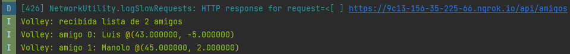

¿Qué ha aparecido en la terminal de `ngrok`?

## 3.3 Pintando chinchetas

El pintado de las “chinchetas” debe hacerse en el hilo principal. Puedes implementar un método llamado por ejemplo `paintAmigosList()` que lo haga, pero ese método debe ser llamado desde el hilo principal.

Hay un problema de asincronía aquí. Para poder pintar la lista de amigos necesitamos por un lado tener la propia lista (que solicitamos vía HTTP pero no sabemos cuándo llegará), y por otro lado que el mapa haya terminado de pintarse, lo cual es otra operación asíncrona pues `osmdroid` va pidiendo a los servidores de OpenStreetMaps las imágenes de cada “baldosa” con las que va componiendo el mapa.

Ambas solicitudes son asíncronas y no sabemos cuál ocurrirá antes. Cuando recibamos la lista se ejecutará el método `onResponse()` que has implementado como parte del *listener* para Volley. Si intentamos pinchar las chinchetas desde dentro de `onResponse()` puede que el mapa aún no esté listo. Este tipo de problemas aparece muy a menudo en el ámbito de la programación asíncrona, hasta el punto de que se han desarrollado nuevos paradigmas y sintaxis para tratar con ello (como RxJava).

En esta sesión optaremos por una solución simple, y daremos por supuesto que, para cuando se reciba la lista de amigos, el mapa estará ya terminado de pintar, por lo que se podrán dibujar las chinchetas encima de él. En el caso de `omsdroid`, además, parece que esta hipótesis no plantea problemas porque, aún si el mapa no se había terminado de dibujar, es posible añadirle chinchetas, que aparecerán más tarde cuando el mapa se dibuje.

Para crear una marca en el mapa (una chincheta) con `omsdroid` implementaremos la siguiente función:

```java
    private void addMarker(double latitud, double longitud, String name) {
        GeoPoint coords = new GeoPoint(latitud, longitud);
        Marker startMarker = new Marker(map);
        startMarker.setPosition(coords);
        startMarker.setAnchor(Marker.ANCHOR_CENTER, Marker.ANCHOR_CENTER);
        startMarker.setTitle(name);
        map.getOverlays().add(startMarker);
    }
```

Este código hace uso de clases implementadas por omsdroid, como `GeoPoint` para contener la latitud y longitud de un punto del mapa, y `Marker` para representar la “chincheta” con una cierta forma y “nombre” asociado (será el nombre del “amigo” que se halla en esa localización).

La función `paintAmigosList()` deberá iterar sobre la lista de amigos (que recibirá como parámetro) y para cada uno llamar a la función `addMarker()` que acabamos de ver.

**Ejercicio**

Implementa el método `paintAmigosList()` e invócalo en la forma apropiada antes descrita.

## 3.4 Actualización de las posiciones de las chinchetas

Además de pintar la posición de los amigos al arrancar la aplicación, deberíamos repintarlos cada cierto tiempo, pues los contenidos de la base de datos pueden cambiar. Para ello, de momento, crearemos un temporizador como el siguiente (donde `UPDATE_PERIOD` es el tiempo deseado entre actualizaciones, en milisegundos, que puedes fijar a 5000 por ejemplo para que se ejecute cada 5 segundos):

```java
Timer timer = new Timer();
TimerTask updateAmigos = new UpdateAmigosPosition();
timer.scheduleAtFixedRate(updateAmigos, 0, UPDATE_PERIOD);
```

`UpdateAmigosPosition` es el nombre de una clase (declarada dentro de la clase principal de la aplicación, para que tenga acceso a sus métodos), que ha de contener un método llamado `run`, desde el que invocaremos la actualización de la lista y el repintado de las chinchetas. Es decir:

```java
class UpdateAmigosPosition extends TimerTask {
    public void run() {
        getAmigosList();
    }
}
```

Añade la actualización periódica al programa. ¿Dónde crees que deberías poner el código que crea el temporizador y lo prepara para que lance la actualización de la lista cada cierto tiempo?

**Nota**. La función `paintAmigosList()` deberá comenzar por borrar las chinchetas antes pintadas, pues de no hacerlo así cada nueva invocación a esta función pintaría chinchetas adicionales encima de las que ya había. Para borrar las chinchetas previas usa `map.getOverlays().clear();` Esta misma situación ocurre con la lista de amigos en `getAmigosList()`, donde deberás vaciar tu lista con el método `clear()` antes de añadir todos los amigos de la respuesta, o de lo contrario se añadirían nuevos `Amigos` en lugar de actualizar los existentes.

**Nota 2**. Debido a un posible bug de omsdroid, aunque el código de pintar chinchetas se ejecute de nuevo, la vista del mapa no se actualiza hasta que el usuario no interactúe de nuevo con ella, por ejemplo tocando la pantalla del móvil. Para evitar este problema añade la siguiente línea una vez has pintado a todos los amigos: `map.getController().scrollBy(0,0);` Esto simulará una acción del usuario (desplazar el mapa, si bien lo desplazamos cero unidades), y eso forzará su repintado, con lo que se verá inmediatamente la actualización de las chinchetas tras su repintado.

Fíjate que estamos realizando la actualización mediante *polling*, lo cual nunca es eficiente, ya que no se puede saber si hay datos más actuales antes de realizar la conexión. Más adelante se solucionará ese problema con la integración de los servicios de notificaciones.

Comprueba que el mapa se repinta correctamente cada cierto tiempo. Una forma sencilla de verificarlo es usar un navegador web para acceder a la tabla de amigos en `http://ip.de.ubuntu/html/amigos` y editar las coordenadas de uno de ellos, o añadir o borrar amigos de la tabla. El mapa debería actualizar las chinchetas adecuadamente.

**Opcional**. Puedes mejorar la apariencia de la información cambiando las chinchetas que omsdroid pinta por defecto por otro icono. Para ello puedes usar `startMarker.setIcon(getResources().getDrawable(R.drawable.icono));` en la función `addMarker()`, pero el icono debe existir en la lista de recursos de la aplicación. Esa lista la puedes ver en el árbol del proyecto, *res > drawable*. Por defecto sólo aparecen ahí dos archivos, correspondientes al icono de la aplicación. Puedes añadir más mediante *File > New > Image Asset* (o *Vector Asset*). Al añadir uno de la categoría “Launcher Icons (Legacy only)” tendrás acceso a muchos iconos predefinidos en el menú “Clip Art”.

Aquí tienes una muestra de cómo puede verse la aplicación con otro icono para las chinchetas.

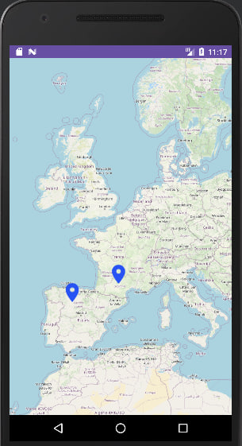

# 4 Actualización de la posición en función del GPS

De momento la única forma en que las chinchetas se pueden mover es si accedes al servidor mediante su interfaz html. Vamos a hacer algo más realista. Se supone que cada amigo lleva un teléfono en el que está corriendo esta aplicación. Por tanto, la aplicación tomará de sensor GPS del teléfono cuáles son sus coordenadas y las enviará a la base de datos, cada vez que se detecte que el teléfono se ha movido.

En una aplicación real cada usuario debería estar identificado por un login y contraseña, debería darse de alta de algún modo, y debería identificarse al instalar la aplicación. Para simplificar vamos a omitir el registro y la necesidad de contraseña. Al arrancar la aplicación se pedirá un nombre al usuario y se usará ese nombre para acceder a la base de datos y actualizar la posición de ese usuario. Se entiende que el nombre proporcionado debe estar ya en la base de datos (lo habrás introducido antes a través de su interfaz HTML, por ejemplo).

## 4.1 Permisos para acceder a la posición

Para que la aplicación pueda acceder al sensor GPS es necesario obtener los permisos apropiados.

Añade al manifiesto los permisos necesarios para acceder a la posición del GPS en caso de que no lo estuvieran ya.

```xml
<!-- Se require para obtener la posición -->
<uses-permission android:name="android.permission.ACCESS_COARSE_LOCATION" />
<uses-permission android:name="android.permission.ACCESS_FINE_LOCATION" />
```

## 4.2 Obtener el nombre del usuario

Nos hace falta saber cuál es el nombre de la persona cuya posición queremos actualizar. Se lo podemos preguntar al usuario de la aplicación en `OnCreate` llamando a la siguiente función que crea un [diálogo](http://developer.android.com/guide/topics/ui/dialogs.html) (observa que en este caso el *layout* lo creamos directamente desde java, en lugar de leerlo de un XML):

```java
public void askUserName() {
      AlertDialog.Builder alert = new AlertDialog.Builder(this);

       alert.setTitle("Settings");
       alert.setMessage("User name:");

       // Crear un EditText para obtener el nombre
       final EditText input = new EditText(this);
       alert.setView(input);

       alert.setPositiveButton("Ok", new DialogInterface.OnClickListener() {
            public void onClick(DialogInterface dialog, int i) {
                mUserName = input.getText().toString();
            }
       });

       alert.setNegativeButton("Cancel", new DialogInterface.OnClickListener() {
            public void onClick(DialogInterface dialog, int i) {
            // Canceled.
            }
       });

       alert.show();
}
```

Hay que declarar la variable `String mUserName = null;` como miembro de la clase.

Esta función, de momento, lo único que hace es guardar el nombre proporcionado por el usuario en la variable `mUserName`, pero más adelante se ocupará también de obtener cuál es el id asociado con ese nombre mediante una consulta al backend.

## 4.3 Obtención de la posición

La obtención de la [posición](http://developer.android.com/guide/topics/location/strategies.html) de un dispositivo móvil es una tarea compleja, ya que hay que adaptarse al ciclo de vida de la aplicación.

En un caso sencillo se puede obtener la posición de la siguiente forma:

- Añade, en el código java, método `onCreate()`, el permiso `Manifest.permission.ACCESS_FINE_LOCATION` a la lista de permisos que se le pasan a la función `requestPermissionsIfNecessary()`, para que cuando se ejecute la aplicación se solicite al usuario este nuevo “permiso delicado”, además del de acceder al almacenamiento.
- Añade, al final de la función `onCreate()` un llamada a `SetupLocation()`, función que implementaremos seguidamente

La función `SetupLocation()` llamada desde el código anterior se ocupa de registrar un *listener* al *Location Manager*. Ese *listener* será invocado cada vez que el GPS detecte un cambio de coordenadas, o cada cierto tiempo, según como haya sido creado. Un ejemplo del código de esta función sería el siguiente:

```java
void SetupLocation() {
    if (ActivityCompat.checkSelfPermission(this,
                              android.Manifest.permission.ACCESS_FINE_LOCATION)
            != PackageManager.PERMISSION_GRANTED
        && ActivityCompat.checkSelfPermission(this,
                              android.Manifest.permission.ACCESS_COARSE_LOCATION)
            != PackageManager.PERMISSION_GRANTED)
     {
        // Verificar por si acaso si tenemos el permiso, y si no
        // no hacemos nada
        return;
    }


    // Se debe adquirir una referencia al Location Manager del sistema
    LocationManager locationManager =
          (LocationManager) this.getSystemService(Context.LOCATION_SERVICE);

    // Se obtiene el mejor provider de posición
    Criteria criteria = new Criteria();
    String  provider = locationManager.getBestProvider(criteria, false);

    // Se crea un listener de la clase que se va a definir luego
    MyLocationListener locationListener = new MyLocationListener();

    // Se registra el listener con el Location Manager para recibir actualizaciones
    // En este caso pedimos que nos notifique la nueva localización
    // si el teléfono se ha movido más de 10 metros
    locationManager.requestLocationUpdates(provider, 0, 10, locationListener);

    // Comprobar si se puede obtener la posición ahora mismo
    Location location = locationManager.getLastKnownLocation(provider);
    if (location != null) {
        // La posición actual es location
    } else {
        // Actualmente no se puede obtener la posición
    }
}
```

Finalmente hay que implementar el *listener*, lo que nos obliga a implementar una serie de métodos de esta interfaz, aún si no los necesitamos (los dejamos vacíos en ese caso):

```java
// Se define un Listener para escuchar por cambios en la posición
class MyLocationListener implements LocationListener {
    @Override
    public void onLocationChanged(Location location) {
        // Se llama cuando hay una nueva posición para ese location provider
        double lati = location.getLatitude();
        double longi = location.getLongitude();
        // AQUI HABRA QUE AÑADIR CODIGO MÁS ADELANTE
        // para actualizar en el backend la posición de este teléfono
        // ...
    }

    // El resto de métodos que debemos implementar los podemos dejar vacíos
    @Override
    public void onStatusChanged(String provider, int status, Bundle extras) {}
    // Se llama cuando se activa el provider
    @Override
    public void onProviderEnabled(String provider) {}
    // Se llama cuando se desactiva el provider
    @Override
    public void onProviderDisabled(String provider) {}
}
```

**Ejercicio**

Implementa adecuadamente todo lo anterior. De momento, cada vez que la posición del teléfono cambie, limítate a imprimir por el *logcat* las nuevas coordenadas desde `onLocationChanged()`. Enseguida las usaremos para actualizar la posición del usuario en la base de datos.

Puedes verificar si lo has hecho bien cambiando a través del emulador las coordenadas del teléfono, y verificando que aparecen en el *logcat*. Puede ayudarte a filtrar ese mensaje entre todos los demás si imprimes las nuevas coordenadas precedidas de una cadena como “GPS changed” o similar.

Lanza la aplicación, concede los permisos que solicita e introduce un nombre de un Amigo existente en tu base de datos. Tras ello, para cambiar las coordenadas del teléfono desde el emulador pincha en el menú de los tres puntitos verticales que hay en la ventana del emulador:

[figure not shown]

Eso abrirá otra ventana que permite manipular diferentes opciones del teléfono emulado, como su *Location* que te permite simular que se halla en cualquier lugar del mundo. Busca un sitio en el mapa que aparece y luego pulsa el botón SET LOCATION. Busca en el *locgat* el mensaje de que la posición ha cambiado.

**NOTA**: Si no te aparece el mapa, puedes añadir ubicaciones manualmente (“Saved Points”). A continuación se proporcionan dos ubicaciones, que puedes almacenar en los ficheros `nuevayork.gpx` y `lyon.gpx` (puedes dejarlos en el Escritorio, por ejemplo):

`nuevayork.gpx`:

```xml
<?xml version="1.0" encoding="UTF-8"?>
<gpx version="1.1" creator="Manual" xmlns="http://www.topografix.com/GPX/1/1">
 <wpt lat="40.7143528" lon="-74.0059731">
   <name>Nueva York</name>
   <desc>Un punto de ejemplo</desc>
 </wpt>
</gpx>
```

`lyon.gpx`:

```xml
<?xml version="1.0" encoding="UTF-8"?>
<gpx version="1.1" creator="Manual" xmlns="http://www.topografix.com/GPX/1/1">
 <wpt lat="45.765" lon="4.834">
   <name>Lyon</name>
   <desc>Un punto de ejemplo</desc>
 </wpt>
</gpx>
```

Carga estos ficheros con el botón “*Import GPX/KML*” y verifica que al cambiar la ubicación entre estas dos ciudades, tu `logcat` informa correctamente que la posición GPS ha cambiado:

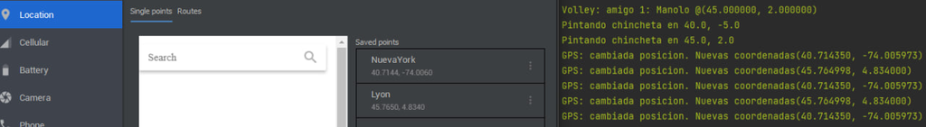

También, si abres la aplicación Google Maps disponible en el emulador, deberías ver como tu ubicación se modifica al cambiar la localización entre estas dos ciudades

## 4.4 Actualización de la posición del usuario

Cada vez que se reciba una actualización en la posición del dispositivo móvil se debe realizar una actualización de la base de datos de la aplicación web. Para ello nuestra api rest tenía preparado un punto de acceso, `PUT /api/amigo/{id}` al que enviar un JSON con las nuevas coordenadas. Sin embargo el problema es que hay que conocer el `id` del usuario en la base de datos, y la aplicación del teléfono sólo conoce el nombre (que el usuario le proporcionó al arrancar). La api rest tiene otro punto de acceso `GET /api/amigo/byName/{nombre}` que busca el nombre en la base de datos y retorna su `id`.

Falta por tanto implementar la funcionalidad para que, cada vez que el GPS nos reporte un cambio de posición, utilicemos Volley para acceder a la API rest, primero para obtener el id a partir del nombre, y seguidamente para actualizar las coordenadas de ese id.

La obtención del `id` no debería suponerte ningún problema, pues es una petición `GET` similar a las que ya hemos hecho antes (en este caso recibe un `JSONObject` en vez de un `JSONArray`). Ésta podríamos hacerla al principio, tras recibir el nombre del usuario, y guardar el `id` resultante en un atributo de la clase, para recordarlo y no tener que consultarlo más.

**Ejercicio**

Implementa un método llamado `getAmigoId()` que obtenga de la base de datos el `id` del usuario a partir de su nombre, y lo guarde en un atributo de la clase (que está inicializado con el valor -1). Imprímelo además por el *logcat* para comprobar que lo estás recibiendo correctamente. Haz que esta petición se haga tan pronto como tenemos el nombre del usuario. En caso de error en la petición (por ejemplo, si el usuario no existe), la variable permanecerá con su valor inicial -1 como indicador de que no tenemos un id válido.

Si estás usando ngrok para obtener una url pública, en la terminal en que lanzaste ngrok podrás ver las peticiones que van llegando, lo que te puede servir para depurar problemas.

Una vez tenemos el `id` del usuario, siempre que sea distinto de -1, podremos usarlo para actualizar sus coordenadas mediante el `PUT` apropiado, cada vez que éstas cambien.

La documentación de Volley no muestra ejemplos de cómo hacer una petición `PUT`, pero no es muy difícil deducir que basta con usar `Request.Method.PUT` en lugar de `Request.Method.GET`, y que debemos crear un objeto `JSONObject` para pasar como parámetro en lugar del `null` que habíamos pasado hasta ahora. Es decir:

```java
JsonObjectRequest objectRequest = new JsonObjectRequest(
    Request.Method.PUT, url_put, jsonToSend,
    new Response.Listener<JSONObject>() {
        ...
    });
queue.add(objectRequest)
```

El objeto `jsonToSend` lo construiríamos en la forma siguiente (no se incluye la gestión de excepciones en este ejemplo):

```java
JSONObject jsonToSend = new JSONObject();
jsonToSend.put("id", id);
jsonToSend.put("lati", latitud);
jsonToSend.put("longi", longitud);
```

**Ejercicio**

Completa en la aplicación móvil la actualización de la posición de usuario (recuerda verificar que el atributo donde guardaste el `id` es distinto de -1, lo que indica que se recuperó con éxito de la base de datos, en caso contrario no se intenta el `PUT`). De nuevo, puedes ayudarte de salidas por pantalla en tu `logcat` para mostrar el éxito o error en la actualización de las coordenadas del usuario.

Prueba a cambiar la posición del GPS a través del emulador y verifica que la aplicación web actualiza la posición (podrás comprobarlo en la tabla de la vista html con un navegador, y también poco después con el movimiento de la chincheta en el móvil, cuando, debido al *polling* se recuperen de nuevo las posiciciones de la base de datos).

Este es un buen momento para hacer un commit con todo tu trabajo, si no lo habías hecho antes, por si acaso estropeas algo al intentar el apartado siguiente.

# 5 Servicios de notificaciones

Los servicios de notificaciones permiten enviar información desde los servidores a los clientes. Estos servicios denominados *Push* evitan que los clientes tengan que solicitar información al servidor sin saber si esa información está disponible (el mecanismo *Pull*). El mecanismo *Push* es más eficiente, ya que reduce el intercambio de información, pero es más difícil de implementar. En concreto se trabajará con el servicio Firebase Cloud Messaging (FCM). Este servicio permite enviar información desde un servidor a clientes Android y también a aplicaciones sobre Chrome. Otros fabricantes, como Apple o Microsoft, tienen servicios equivalentes.

El servicio [Firebase Cloud Messaging](https://firebase.google.com/docs/cloud-messaging) (FCM) permite que servidores propios, por ejemplo el servidor Flask de la aplicación amigos, envíe información a aplicaciones que se ejecutan sobre Android, iOS o clientes Web. Además, esa información se transmite a los clientes Android utilizando conexiones existentes de otros servicios de Google, con lo que el tráfico de información resulta muy eficiente.

Los elementos que participan en el intercambio de mensajes son los siguientes:

[figure not shown]

- Servidor de la aplicación (Trusted Environment en la figura) es el servidor que contiene la información que los clientes necesitan. En nuestro caso será la aplicación amigos (también se pueden enviar mensajes a los dispositivos a través de una consola web que Firebase proporciona, útil para pruebas).
- Cliente: es la aplicación Android que usa la información del servidor (también puede ser una aplicación iOS o Web)
- Servidores FCM: son los servidores proporcionados por Google que se encargarán de hacer llegar el mensaje desde el servidor de la aplicación hasta la aplicación cliente.

## 5.1 Integración de FCM en la aplicación

En las versiones recientes de Android Studio (>2.2) es teóricamente muy sencillo añadir el soporte para FCM utilizando el asistente. Sin embargo en la práctica pueden aparecer problemas debido a la continua aparición de nuevas versiones del software.

En el menú *Tools* elige *Firebase* y se abrirá un asistente en el que puedes elegir qué servicio de los varios que ofrece Firebase es el que quieres incorporar a tu app. Elige *Cloud Messaging* y pulsa en el enlace *Set Up Firebase Cloud Messaging*.

1. En el asistente que aparece pulsa el botón *Connect to Firebase*.

   Si todo va bien, al pulsar el boton *Connect to Firebase* te abrirá un navegador Web para que inicies sesión en Google. Suministra tus credenciales y dale los permisos que te solicita para que Android Studio pueda gestionar tus proyectos. Esto hará que Android Studio inice sesión en tu cuenta de Google y a partir de ahi puedas continuar haciendo el resto del *setup* desde el propio Android Studio
2. En el diálogo que te aparece en el navegador tras iniciar sesión te está pidiendo que, o bien utilices un proyecto `Firebase` previo, o bien crees uno nuevo, para conectar esta aplicación con él. Crea uno nuevo con el nombre `amigos`, y en el siguiente paso deshabilita el uso de Google Analytics. Finalmente, pulsa en *Crear Proyecto*.

   Durante un rato, en el navegador verás un proceso de creación del proyecto. Firebase hará las acciones apropiadas para crear (en los servidores de Google) un proyecto nuevo y conectar con él tu aplicación. Esto lo hace bajo tus credenciales. Tras el proceso, si todo ha ido bien, verás el siguiente mensaje:

[figure not shown]

   Cuando pulses en conectar, la interfaz de Android Studio cambiará para notificar la conexión con Firebase:

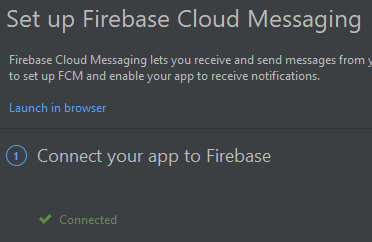

   Si este paso fallara, puedes pulsar de nuevo *Connect to Firebase* en el asistente. Es probable que el proyecto Firebase haya sido creado correctamente en los servidores Google pero haya fallado la descarga de los archivos de configuración necesarios para integrarlo en nuestra app. Normalmente un reintento arregla este problema.

Las modificaciones que Android Studio ha añadido automáticamente a los ficheros `.gradle` puede que no estén actualizadas si no usas la última versión del IDE. Vamos a asegurarnos de tener las versiones adecuadas.

Prueba a compilar la aplicación tras estos cambios. Aunque no hemos modificado el código java todavía, sí se han introducido dependencias nuevas, por lo que conviene verificar que todo siga compilando correctamente.

Si te da errores de compilación o de sincronización del gradle, debes hacer los cambios siguientes en el fichero `build.gradle.kts (Module: app)`:

- Dentro de las llaves de `defaultConfig{ ... }` añade una línea que diga `multiDexEnabled true`
- Dentro de las llaves `dependencies{ ... }` añade una nueva que diga `implementation("androidx.multidex:multidex:2.0.1")`
- Sincroniza de nuevo el proyecto, compila y verifica que no hay errores. La aplicación debería seguir funcionando tal y como estaba tras completar la Sección 4.

Tras lo anterior el proyecto estará configurado para poder utilizar FCM. Sólo queda añadir el código necesario en la aplicación para recibir los mensajes. El asistente muestra ejemplos de código de cómo proseguir, pero esos ejemplos usan características obsoletas y no funcionan. Lo que sigue del guion de prácticas son esos mismos fragmentos explicados y adaptados a la versión actual.

### 5.1.1 Obtener token del dispositivo

Cuando el servidor flask quiera enviar un mensaje a un dispositivo concreto, necesitará conocer su *token* (un identificador único). Es para esto que habíamos incorporado a la base de datos “amigos” un campo “device”, que de momento está aún en blanco para todos los usuarios (o debería estar).

Debemos incluir código para que, cuando nuestra app arranque, obtenga un token de dispositivo.

- Edita el *manifest* y añade dentro de `<application>` un nuevo servicio:

  ```xml
  <service
      android:name=".MyFirebaseMessagingService"
      android:exported="false">
      <intent-filter>
          <action android:name="com.google.firebase.INSTANCE_ID_EVENT"/>
          <action android:name="com.google.firebase.MESSAGING_EVENT" />
      </intent-filter>
  </service>
  ```

  Esto declara un nuevo componente de la aplicación, de tipo servicio. Pero aún tenemos que implementarlo (mientras no lo hagamos este fichero nos mostrará en rojo el nombre del servicio).
- Crea una nueva clase llamada `MyFirebaseMessagingService` (el mismo nombre que hemos puesto en el atributo `android:name` de este servicio en el *manifest*). Esta clase debe heredar de `FirebaseMessagingService` e implementar el método `onNewToken()`, así por ejemplo:

  ```java
  public class MyFirebaseMessagingService extends FirebaseMessagingService {
      @Override
      public void onNewToken(String token) {
          System.out.println("FCM Refreshed token: " + token);
      }
  }
  ```

Cuando arranca la aplicación, arrancará también este servicio que acabamos de crear, el cual creará un token único para el dispositivo en que se está ejecutando. En este caso nos limitamos a imprimir por el *logcat* el token en cuestión.

**Ejercicio**

Implementa lo que se ha descrito más arriba y ejecuta el programa. En principio todo debería seguir funcionando como antes (recuerda tener en marcha el servidor y el túnel ngrok).

Observa en el *logcat* el mensaje (filtra por el texto “FCM Refreshed token”) y si todo va bien podrás ver el token de dispositivo que se le ha asignado. Es una larga cadena alfanumérica, como por ejemplo `"dwYnN4kASjC4TEXYk5Vl2Z:APA91b...f1gRvu_"`. Si no lo ves posiblemente se deba a que no es la primera vez que has ejecutado esta aplicación desde que le has añadido soporte FireBase. El token se genera sólo la primera vez que la ejecutas, por lo que sólo esa primera vez se ejecutará el método `onNewToken()`. Si te ocurre esto no te preocupes, de todas formas es posible obtener el token más adelante, como explicaremos seguidamente.

### 5.1.2 Registro del token dispositivo ante nuestro servidor

El token mencionado en el ejercicio anterior es el valor que deberemos guardar en la base de datos del *backend*, en el campo `device` asociado con el usuario cuyo nombre solicitamos al arrancar la app. Para ello habría que enviárselo a la aplicación Flask, mediante un PUT al usuario apropiado. El problema es que seguramente no sabemos aún quién es el usuario, y que probablemente tengamos el token mucho antes de que el usuario haya escrito su nombre, pues el token se genera casi inmediatamente durante el arranque (y sólo la primera vez que se ejecuta la aplicación y no vuelve a generarse de nuevo a menos que la aplicación sea reinstalada).

Para obtener el valor del token en cualquier otro momento (por ejemplo, desde la Actividad principal del mapa), será necesario un código como el siguiente:

```java
public void getFirebaseToken() {
    FirebaseMessaging.getInstance().getToken()
            .addOnCompleteListener(new OnCompleteListener<String>() {
                @Override
                public void onComplete(@NonNull Task<String> task) {
                    String token = task.getResult();
                    System.out.println("FCM getFirebaseId() ->" + token);
                }
            });
}
```

Se trata de código asíncrono. El método `getToken()` retorna una promesa que se resolverá cuando llegue la respuesta. Mediante `.addOnCompleteListener()` se añade a la promesa una función para que se ejecute cuando la respuesta llegue. La función es `onComplete()` y el valor que recibe como parámetro es la promesa resuelta (`task`). Invocando su método `getResult()` obtendremos el valor resuelto de la promesa, es decir, el Token que Firebase nos haya asignado.

**Ejercicio**

Modifica el método antes dado como ejemplo para que, además de imprimir el token en el *logcat* lo guarde para que pueda ser usado desde otros métodos. Invoca este método desde el `onCreate()` para tener el token cuanto antes.

Edita la función `getAmigoId()` para que, tras recibir correctamente el `id` del usuario, invoque al método `updateDeviceToken()` que describiremos a continuación.

Implementa en la clase `MainActivity` un método llamado `updateDeviceToken()` que haga lo siguiente:

- Si el `id` del usuario (que has guardado en una atributo del objeto desde el método `getAmigoId()`) es -1, retorna sin hacer nada. Este caso no debería ocurrir, pues cuando la función es invocada es porque ya tenemos un id válido, pero implementamos esta comprobación por si acaso.
- Obtiene el token de dispositivo generado por Firebase accediendo al atributo de clase en la que lo hayas guardado desde el método `getFirebaseToken()`. Si ese atributo aún vale `null`, la función retorna sin hacer nada. De nuevo esto no debería ocurrir pues para cuando la función que estamos escribiendo sea invocada, el token ya estará generado, pero de nuevo hacemos la comprobación por si acaso.
- Si todo ha ido bien, hacemos un `PUT /api/amigo/{id}` enviando un JSON que contenga en el campo `"device"` el token recuperado en el paso anterior. En principio no necesitamos incluir más campos en el JSON (aunque eso depende de que hayas escrito el servicio Flask para que funcione cuando no se le especifiquen algunos campos).

Compila y ejecuta la app. Para comprobar si ha funcionado correctamente, busca en el *logcat* el mensaje con el Token y a la vez mira en el servidor Flask (por ejemplo, en su interfaz HTML) si ha actualizado el campo `"device"` del usuario en cuestión.

### 5.1.3 Recibir mensajes del servidor

Al tener integrado Firebase en nuestra app, ya podríamos enviarle mensajes al dispositivo, que el teléfono recibiría y mostraría en el área de notificaciones si la aplicación “Amigos” se está ejecutando en segundo plano, o incluso si no se está ejecutando (pero está instalada).

Probemos esto.

**Experimento**

En el simulador del móvil, asegúrate de que la aplicación “Amigos” no está en primer plano (puede no estar siquiera ejecutándose tampoco en segundo plano, pero ha de estar instalada).

Usa un navegador Web en tu ordenador para ir a la [Consola de Firebase](https://console.firebase.google.com).

Verás en ella el proyecto `Amigos`, que fue creado cuando desde Android Studio utilizamos el asistente Firebase (y le dimos permiso para crear proyectos con Google en nuestro nombre). Pulsa sobre ese proyecto en la consola Web de Firebase.

En el menú de la izquierda, busca “Cloud Messaging” (está en la categoría “Todos los productos”) y pulsa sobre el servicio. Te llevará a una página en la que verás un botón “Crear la primera campaña”. Púlsalo y elige “Mensajes de Firebase Notifications” en la siguiente ventana que aparece, y después “Crear”.

Comprueba en el simulador del móvil que ha llegado un mensaje al área de notificaciones. Si pulsas en él te pasará la aplicación a primer plano.

**Nota**. En ocasiones la consola de FireBase puede tardar mucho tiempo en enviar el mensaje. Si no te aparece en el móvil no importa. Aparecerá tarde o temprano. Continúa con la práctica.

Aunque los mensajes llegan al teléfono, nuestra aplicación no es notificada. No tiene forma de reaccionar a esos mensajes. Nuestro objetivo (la razón por la que usamos Firebase Cloud Messaging) era evitar el *polling* en el cliente, es decir, que en lugar de pedir al servidor la lista de amigos cada N segundos, se la pidamos sólo cuando haya cambiado la información del servidor, es decir, cuando recibamos una notificación vía FCM (luego veremos cómo hacer que Flask envíe esa notificación).

Para ello hay que añadir a la clase `MyFirebaseMessagingService` el método `onMessageReceived()`. El siguiente ejemplo muestra cómo sería esta clase. En este ejemplo la clase se limita a imprimir en el *logcat* el mensaje recibido:

```java
public class MyFirebaseMessagingService extends FirebaseMessagingService {
    @Override
    public void onMessageReceived(RemoteMessage remoteMessage) {
        System.out.println("FCM: From " + remoteMessage.getFrom());

        // El mensaje en sí son datos que pueda enviar el servidor
        // en forma de cadena que contiene una especie de JSON
        // No lo usaremos, por lo que vendrá vacío
        if (remoteMessage.getData().size() > 0) {
            System.out.println("FCM: Message = " + remoteMessage.getData());
        }

        // La notificación es el texto que aparecería en la barra
        // de notificaciones, el que se especifica en la consola
        // web de Firebase
        if (remoteMessage.getNotification() != null) {
            System.out.println("FCM: Notification Body ="
                    + remoteMessage.getNotification().getBody());
        }
    }
}
```

**Ejercicio**

Implementa el servicio descrito más arriba. Compila y ejecuta.

Mientras la aplicación está funcionando, envíale un mensaje creado desde la consola web de Firebase.

Revisa el *logcat* (filtra por la cadena “FCM” y comprueba que se ha recibido y se ha ejecutado la función `onMessageReceived)

**Nota**. De nuevo, si no ves aparecer el mensaje continúa con la práctica. Es posible que la consola FireBase esté tardando mucho en enviarlo.

Ya tenemos todo listo para terminar de implementar el cliente.

### 5.1.4 Actualizar posiciones de amigos sólo cuando es necesario

Elimina o comenta el código que creaba un temporizador para ejecutar `getAmigosList()` periódicamente. Haz que se ejecute sólo una vez, cuando el programa arranca. Comprueba que la aplicación arranca y pinta las chinchetas en el mapa una vez (la terminal en que ejecutas ngrok te muestra las peticiones HTTP que está recibiendo el *backend*, comprueba que sólo recibe una solicitando la lista de amigos).

La idea, tras eliminar el *polling*, es que el cliente invoque `getAmigosList()` sólo cuando le llegue un mensaje a través de FCM. El cuerpo del mensaje o el texto de la notificación que recibamos es irrelevante en este caso. Simplemente por recibir un mensaje asumiremos que algo ha cambiado en la base de datos, por lo que solicitaremos la nueva lista de amigos y la repintaremos.

Necesitamos por tanto transmitir el evento de que se ha recibido un mensaje de un componente a otro de nuestra aplicación. Para esta situación Android tiene los *Broadcast Receivers*.

En el componente `MyFirebaseMessagingService`, dentro de la función `onMessageReceived()` añade el código siguiente:

```java
    Intent updateFromServer = new Intent("updateFromServer");
    LocalBroadcastManager.getInstance(this).sendBroadcast(updateFromServer);
```

Esto crea un *intent* (que es una estructura de datos frecuentemente usada en Android para transmitir información entre componentes, entre otras cosas). La cadena `"updateFromServer"` sirve para identificar a este *intent* cuando sea recibido en otra parte de la aplicación, y así diferenciarlo de otros *intents* y poder tomar diferentes acciones. Seguidamente envía ese *intent* a través del `LocalBroadcastManager`. Esto hará que los restantes componentes de la aplicación (en particular, la actividad principal que pinta el mapa) lo reciban, siempre que hayan registrado una clase para recibir estos mensajes.

Para que otro componente reciba el mensaje debes instanciar un objeto de la clase `BroadcastReceiver`, que implemente el método `onReceive()`. Después debe registrar ese objeto a la vez que un filtro de *intents*, para que el objeto no reciba cualquier *intent*, sino sólo los que encajen con ese filtro.

Por ejemplo, el siguiente código registra un receptor de mensajes para los intent cuya acción sea `"updateFromServer"`, que es la que se usó en la creación del *intent* en el código antes visto.

```java
mHandlerForBroadcast = new BroadcastReceiver() {
    @Override
    public void onReceive(Context context, Intent intent) {
        System.out.println("Broadcast: received = " + intent.getAction());
    }
};
LocalBroadcastManager.getInstance(this).registerReceiver(
        mHandlerForBroadcast,
        new IntentFilter("updateFromServer"));
```

**Ejercicio**

Implementa en la clase `MainActivity` un método que contenga el código anterior. Invoca ese método desde `onCreate()`.

Modifica la clase `MyFirebaseMessagingService` para que incluya las líneas que crean el *intent* y lo envían por *Local Broadcast*

Ejecuta el programa y vigila el *logcat* (puedes filtrar por la cadena `"Broadcast"`). Desde la consola web de Firebase envía un mensaje. Verifica que en el *logcat* aparece la recepción del *intent*. (**Nota**: si no aparece sigue con la práctica, la consola de FireBase puede tardar mucho en enviar el mensaje).

Esto implica que la actividad principal ahora ya “se entera” de cuándo la app ha recibido una notificación FCM. En ese momento será cuando deba solicitar de nuevo la lista de amigos.

Añade la llamada a `getAmigosList()` en el punto adecuado, para que se produzca cuando se reciba la notificación.

Ejecuta el programa. Usa la consola web de Firebase para enviar una notificación y vigila la terminal donde tienes abierto el túnel con ngrok. Deberías ver que el cliente hace una nueva petición `GET` cuando recibe la notificación FCM.

### 5.1.5 Detalle final

Aunque lo anterior funcione, no es del todo correcto. La función que hemos añadido a la actividad principal registra un componente que queda a la escucha de broadcast, pero no lo desregistra nunca. Si la actividad muere (por ejemplo, el teléfono gira), el componente seguirá esperando mensajes. Al re-crear la actividad (por ejemplo, tras un giro del teléfono) lo registraríamos de nuevo. Si giramos el teléfono varias veces podríamos acabar con varios componentes escuchando por mensajes broadcast, y todos ellos se activarían ante el *intent* `"updateFromServer"` (lanzando por tanto varias peticiones al *backend*).

Para evitarlo, hay que des-registrar el componente que escucha cuando la aplicación pasa al modo *Paused*, y registrarlo de nuevo si pasa por el modo *Resumed*. Los métodos siguientes serían para eso:

```java
    @Override
    protected void onResume() {
        super.onResume();
        map.onResume(); //needed for compass, my location overlays, v6.0.0 and up
        LocalBroadcastManager.getInstance(this).registerReceiver(
                mHandlerForBroadcast,
                new IntentFilter("updateFromServer"));
    }

    @Override
    protected void onPause() {
        LocalBroadcastManager.getInstance(this)
                             .unregisterReceiver(mHandlerForBroadcast);
        super.onPause();
        map.onPause();  //needed for compass, my location overlays, v6.0.0 and up
    }
```

## 5.2 Integración de FCM en el *backend*

La parte del cliente está terminada. El último paso consiste en que, en lugar de generar las notificaciones desde la consola web de Firebase, lo hagamos desde la aplicación Flask cuando la base de datos sea modificada.

La idea es que cuando nuestro *backend* reciba una actualización de coordenadas GPS (porque el teléfono de alguno de los usuarios se ha movido más de 10 metros y por tanto ese teléfono ha hecho un `PUT` a la base de datos), entonces Flask se ponga en contacto con los servidores FCM y les pida que manden la notificación a la aplicación. Ya hemos visto que cuando ésta recibe la notificación solicita la lista actualizada, por lo que el objetivo final estaría completado.

### 5.2.1 Enviando notificaciones desde python

Para enviar una notificación usando FCM desde nuestro servidor Ubuntu podemos usar Python (o cualquier lenguaje de programación). Basta saber que los servidores de Firebase proporcionan una API REST, y cuáles son las cabeceras y datos que hay que pasarles con las peticiones que les hagamos. Esta API está descrita en la documentación de Firebase.

Ni siquiera necesitamos conocer esos detalles si usamos una biblioteca que los implemente por nosotros, como es el caso de la `pyfcm` en el caso de Python.

Instala `pyfcm` en el entorno virtual en que teníamos instalado Flask (es decir, activa ese entorno y ejecuta `pip install pyfcm` dentro de él)

Un sencillo ejemplo de código python que envía una notificación a nuestro teléfono usando FCM sería el siguiente:

```python
from pyfcm import FCMNotification

push_service = FCMNotification(
                    api_key="AIza...JQtE")
registration_id = "eBzYFzwyID0:APA91...vhW0"
message_title = "Hola desde Python!"
message_body = "Este mensaje ha sido enviado desde python"

result = push_service.notify_single_device(
                        registration_id=registration_id,
                        message_title=message_title,
                        message_body=message_body)
print(result)
```

Debes averiguar cuáles son los valores correctos a rellenar para la `api_key` y el `registration_id`, en la forma siguiente:

- La `api_key` la obtienes en la consola Firebase. Dentro del proyecto “Amigos”, en el menú de la izquierda justo debajo del logo de Firebase hay un icono con una tuerca. Púlsalo y elige “Configuración del proyecto” y después ve a la pestaña “Cloud Messaging”. Allí verás una sección para la (V1) Habilitada y para la (heredada) deshabilitada.

  Para el uso con `pyfcm` necesitamos la versión (heredada) por lo que deberás pulsar en los tres puntos de la derecha, abrir el enlace que aparece y pulsar sobre “Habilitar” en la web que aparece. Una vez hecho, refresca la web de Firebase y podrás ver tu clave:

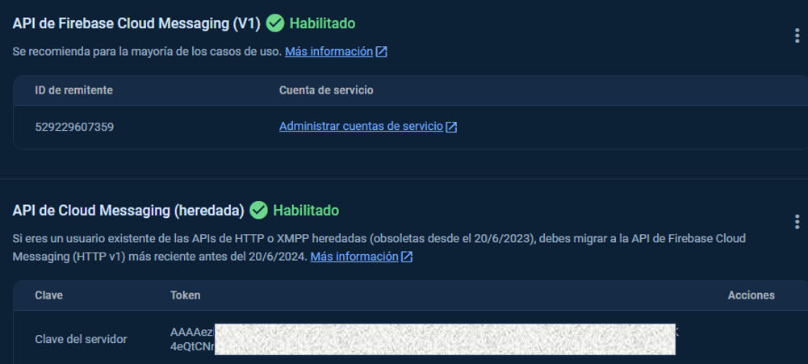

  La larga cadena que comienza por AAA es la clave que debes copiar en `api_key` (No es buena política meter estas claves en el código, pues el código suele terminar en un repositorio git y por tanto la clave ser visible para quienes tengan acceso al repo. Lo correcto sería que el script Python tomara la api_key de una variable de entorno, pero este script de prueba no lo vamos a poner bajo control de versiones, de modo que puedes dejarlo así).
- El `registration_id` es el *id* del dispositivo, el cual pudiste ver en el *logcat* de la ejecución de la aplicación, o también en la base de datos (interfaz web de amigos), pues es el valor del campo “device” para el usuario.

Si completas el código anterior y lo ejecutas, el teléfono con el *id* suministrado debería recibir un mensaje. Si la aplicación “Amigos” no se está ejecutando en ese teléfono, el mensaje se verá en la barra de notificaciones. Si se está ejecutando, en cambio, no se verá porque el mensaje será consumido por la aplicación, pero deberías poder verlo en el *logcat* de Android Studio, pues lo estábamos imprimiendo allí cuando llegaba.

Prueba el código anterior y verifica que el mensaje llega al teléfono.

**Nota**. Ahora sí, el mensaje deberá llegar al teléfono de forma casi instantánea, ya que no es la consola FireBase quien lo envía y quien a veces introduce retrasos. La aplicación Python lo envía al servidor FireBase y éste lo reenvía inmediatamente al teléfono con el token suministrado.

Se pueden enviar mensajes a varios dispositivos en una sola llamada, si tienes una lista con los *id* de los dispositivos en cuestión. Así:

```python
registration_ids = [
        "eBzYFzwyID0:APA91...vhW0",
        "zxjkasloHS1:APA21...1jkv",
        "wJbasTUajH1:IQU92...uYsh"
        ]
result = push_service.notify_multiple_devices(
                        registration_ids=registration_ids,
                        message_title=message_title,
                        message_body=message_body)
```

### 5.2.2 Integración con Flask

Como ejercicio final, debes:

- Modificar la aplicación Flask para añadir un módulo `app/fcm.py` que contenga la función `notificar_amigos()`.

  Esta función recibirá un parámetro que será el “body” de la notificación a enviar (el “title” es irrelevante, podemos poner “Amigos”).

  La función obtendrá la lista de amigos de la base de datos e iterará por los elementos del resultado, creando una lista de *ids* a partir de todos los usuarios cuyo campo `"device"` no esté vacío. Usará `.notify_multiple_devices()` para enviar una notificación a todos los *ids* de esa lista.
- Modificar `app/api/views.py` para que, cuando se modifique la base de datos invoque `fcm.notificar_amigos()`. El parámetro a pasar será una cadena que describa qué ocurrió (por ejemplo: “Nuevo amigo”, “Amigo borrado”, “Amigo se mueve”).
- Modificar `app/html/views.py` para que, cuando se modifique la base de datos vía web, invoque `fcm.notificar_amigos()` con el parámetro apropiado (ver punto anterior).
- Modificar el `Dockerfile` en que se creaba la imagen Flask para que instale también `pyfcm`.
- Re-crear la imagen docker (poniéndole un *tag* diferente) y lanzarla. Verificar con `docker logs` que no hay errores en el arranque.

Convendría, por seguridad, que la *api key* necesaria para conectar con Firebase no formara parte del código fuente, sino que se tomara de una variable de entorno que le pases a Docker al lanzar el contenedor.

Comprueba que, si cambias las coordenadas de algún amigo a través de la vista html del servidor, el teléfono recibe el mensaje FCM indicando el cambio y actualiza la chincheta.

Comprueba que, si cambias las coordenadas del usuario a través del emulador Android, ésto causa que se reciba un mensaje FCM indicando el cambio.

# 6 Repositorio Git

Durante el desarrollo de esta práctica habrás ido guardando las diferentes versiones por las que iba pasando la app android desde el propio Android Studio, a través de su menú VCS.

Estos cambios, como sucedió en la sesión anterior, van siendo guardados en un repositorio local. Al igual que hicimos en la sesión anterior, ese repositorio debe conectarse con otro en Bitbucket (puedes llamarlo por ejemplo `ing_serv_p7_2`), para tener una copia de seguridad y para poder colaborar con tu compañero/a.

Cuando la práctica esté terminada, integra ese repositorio con el principal de la asignatura, como ya hiciste en la sesión anterior para el caso de la app “Converter”. Repetimos aquí cómo se haría:

1. En tu máquina Ubuntu entra en el repositorio “principal” en que tienes el resto de sesiones.
2. Asegúrate de que existe la carpeta `P7` que habrás creado en la sesión anterior. Si no, créala ahora.
3. Ejecuta el comando siguiente, cambiando la URL por la que tenga el repositorio Bitbucket que creaste para esta práctica Android:

   ```bash
   $ git subtree add -P P7/amigos \
     https://tu_usuario@bitbucket.org/creador/ing_serv_p7_2.git \
     master
   ```

4. Verifica que en `P7/amigos` tienes los ficheros de la práctica de Android.
5. Verifica que `git log` te muestra tanto el historial de la práctica de Android como parte del historial previo del repositorio “principal”. Has incorporado el repositorio.
6. Sube los cambios al repositorio principal con `git push`. Comprueba en Bitbucket que aparecen en el repositorio principal los *commits* y archivos de esta práctica de Android.

Si después de haber integrado el repositorio sigues trabajando en la práctica, deberás incorporar los cambios al repositorio usado por Android Studio (a través de su menú *VCS*), subir esos cambios a Bitbucket (a través de *VCS > Git > Push*) y ejecutar en la máquina Ubuntu los siguientes comandos para actualizar el repositorio principal que compartes con el profesor:

```bash
$ git subtree pull -P P7/amigos \
  https://tu_usuario@bitbucket.org/creador/ing_serv_p7_2.git \
  master
$ git push
```